# Maxwell_hmwrk_1

The below section answers questions from homework 1 section 1

```python
import pandas as pd
import numpy as np
import matplotlib.pyplot as plt
flights = pd.read_csv('nycflights13.csv.bz2', sep = '\t')
flights.head(3)
```

|  | year | month | day | dep_time | sched_dep_time | dep_delay | arr_time | sched_arr_time | arr_delay | carrier | flight | tailnum | origin | dest | air_time | distance | hour | minute | time_hour |
| --- | --- | --- | --- | --- | --- | --- | --- | --- | --- | --- | --- | --- | --- | --- | --- | --- | --- | --- | --- |
| 0 | 2013 | 1 | 1 | 517.0 | 515 | 2.0 | 830.0 | 819 | 11.0 | UA | 1545 | N14228 | EWR | IAH | 227.0 | 1400 | 5 | 15 | 2013-01-01T10:00:00Z |
| 1 | 2013 | 1 | 1 | 533.0 | 529 | 4.0 | 850.0 | 830 | 20.0 | UA | 1714 | N24211 | LGA | IAH | 227.0 | 1416 | 5 | 29 | 2013-01-01T10:00:00Z |
| 2 | 2013 | 1 | 1 | 542.0 | 540 | 2.0 | 923.0 | 850 | 33.0 | AA | 1141 | N619AA | JFK | MIA | 160.0 | 1089 | 5 | 40 | 2013-01-01T10:00:00Z |

```python
#arbitrarily picks year as the column to count how many rows are in the DF
flights.year.count()
```

```
336776
```

```python
#the number of airports in the data flights fly out of
flights.origin.nunique()
```

```
3
```

```python
#the three airports in the data that flights fly out of
flights.origin.values[0:3]
```

```
array(['EWR', 'LGA', 'JFK'], dtype=object)
```

```python
#filters by 2013 and the counts the unique number of destinations in the data
flights[np.equal(flights.year, 2013)].dest.nunique()
```

```
105
```

```python
#filters by the destination airport of SEA and then counts
flights[np.equal(flights.dest, 'SEA')].dest.count()
```

```
3923
```

```python
#filters by destination equal to GAG, the airport in spokane
flights[np.equal(flights.dest, 'GAG')].dest.count()
```

```
0
```

```python
#filters dest with a regex and then counts the result. The answer is that all of the destinations follow the three capital letters format
flights[np.equal(flights.dest.str.match(pat = '[A-Z]{3}'), False)].dest.count()
```

```
0
```

The below section answers questions from homework 1 section 2

```python
#the mean delay in the departure
flights.dep_delay.mean()
```

```
12.639070257304708
```

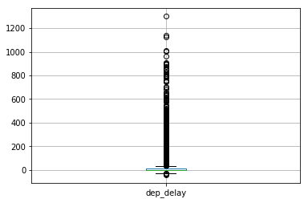

```python
flights.boxplot(column = 'dep_delay')
```

It could be argued that some of the highest delays are suspect, however I think in terms of invalid data that the negative values provide a better argument. Airplanes leaving early is a bad business model, and unlikely to be the case.

```python
flights.year.count() - flights.dep_delay.count()
```

```
8255
```

there are also 8,255 flights for which the departure delay is missing

```python
flights.groupby(flights.dest).dep_delay.mean().nlargest(3)
```

```
dest
CAE    35.570093
TUL    34.906355
OKC    30.568807
Name: dep_delay, dtype: float64
```

CAE, TUL and OKC have the largest mean departure delay times out of any destinations in the data set

```python
#creates a new column that is the month.day
flights['date'] = flights['month'].astype('str') + '.' + flights['day'].astype('str')
```

```
<function matplotlib.pyplot.show(*args, **kw)>
```

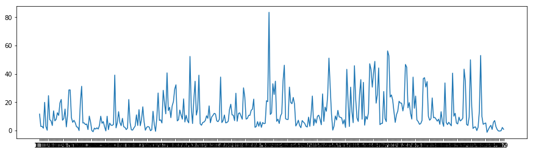

```python
#takes the mean of all departure delays on any day
delay_by_date = flights.groupby(flights.date, as_index = False).dep_delay.mean()

#plotting
plt.figure(figsize = (15,4))
plt.plot(delay_by_date['date'], delay_by_date.dep_delay)
plt.show
```

```python
#groups the flights by month and takes the mean of each month
flights.groupby(flights.month, as_index = False).dep_delay.mean()
```

|  | month | dep_delay |
| --- | --- | --- |
| 0 | 1 | 10.036665 |
| 1 | 2 | 10.816843 |
| 2 | 3 | 13.227076 |
| 3 | 4 | 13.938038 |
| 4 | 5 | 12.986859 |
| 5 | 6 | 20.846332 |
| 6 | 7 | 21.727787 |
| 7 | 8 | 12.611040 |
| 8 | 9 | 6.722476 |
| 9 | 10 | 6.243988 |
| 10 | 11 | 5.435362 |
| 11 | 12 | 16.576688 |

the above table further suggests that seaon/weather may not be a consistent contributor. Hard to say, as weather is poorly operationalized by month.

```
<function matplotlib.pyplot.show(*args, **kw)>
```

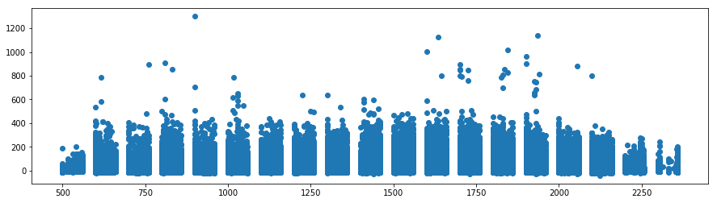

```python
#plots departure time against scheduled departure time
plt.figure(figsize = (15,4))
plt.scatter(flights.sched_dep_time, flights.dep_delay)
plt.show
```

This graph is so weird looking. Obviously the white gaps are a product of the time data jumping from hour and 59 minutes to the next hour. But it also suggests no obvious trend in departure delays as related to weather.

This of course, is becuase a 'foggy morning' is in no way distinguishable from a not 'foggy morning' in our data.

```
<function matplotlib.pyplot.show(*args, **kw)>
```

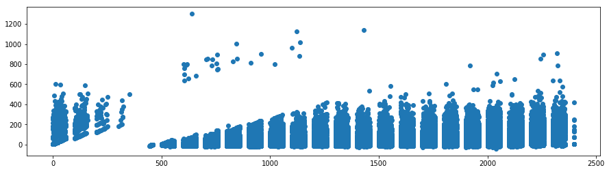

```python
#plots departure time against departure delay
plt.figure(figsize = (15,4))
plt.scatter(flights.dep_time, flights.dep_delay)
plt.show
```

This is a lot more more interesting(still weird).

observation 1) strict increase in minimum delays from about midnight to about three thirty am. observation 2) no departures between three thirty am and four thirty am. observation 3) noticeable increase in likely departure delay starting at about five am.

In conversation with the above graph that showed no departures scheduled between midnight and five am, and the three observations above, this visualization suggests that a baseline likelihood of departure delay does seem to increase throughout the day. This is likely due to the accumulation of delays from previous flights.

the problem I see with these questions is that 'weather' is a concept. We can operationalize it via windspeed or temperature or rainfall or visibility...but none of those things are in our data. Yes in aggregate those might have patterns that correlate with time of year, but to make those claims on a national scale(for a country like the US) is silly. In addition, a flight path crosses multiple locations for each of which there would be a different pattern of weather correlating to time of year.

The following section is for the homework 1 section 3

```python
#filters to the 2013 flights to MCO
MCO_2013 = flights[np.logical_and(flights.year == 2013, flights.dest == 'MCO')]
```

```python
MCO_2013.dest.count()
```

```
14082
```

There were 14,082 flights from NYC to MCO in 2013

```python
MCO_2013.carrier.nunique()
```

```
4
```

there are four different airlines that flew from NYC to MCO in 2013

```python
#dest chosen for the count function so that there would be no missing data
MCO_2013.groupby(MCO_2013.carrier, as_index = False).dest.count()
```

|  | carrier | dest |
| --- | --- | --- |
| 0 | AA | 730 |
| 1 | B6 | 6472 |
| 2 | DL | 3663 |
| 3 | UA | 3217 |

```python
MCO_2013.tailnum.nunique()
```

```
1200
```

1200 unique airplanes flew from NYC to MCO in 2013

```python
MCO_2013.groupby(MCO_2013.origin).origin.count()
```

```
origin
EWR    4941
JFK    5464
LGA    3677
Name: origin, dtype: int64
```

```python
#filters by flights to PDX
pdx = flights[np.equal(flights.dest, 'PDX')]

#removes NAN values and converts arr_delay to int dtype
pdx = pdx.dropna()
pdx['arr_delay'] = pdx.arr_delay.apply(lambda x: int(x))

#counts the flights delayed by more than 15 min then divides by the total count
pdx[np.greater(pdx.arr_delay, 15)].dest.count() / pdx.dest.count()
```

```
0.2615499254843517
```

```python
#groups by origin and then counts
total_pdx = pdx.groupby(pdx.origin).arr_delay.count()

#filters by delay > 15, then groups and counts
delayed_pdx = pdx[np.greater(pdx.arr_delay, 15)]
delayed_pdx = delayed_pdx.groupby(pdx.origin).arr_delay.count()

delayed_pdx / total_pdx
```

```
origin
EWR    0.236234
JFK    0.279846
Name: arr_delay, dtype: float64
```

A lower percentage of flights that depart from EWR to PDX arrive more than 15 minutes late than flights that depart from JFK

The following section is for homework 1 section 4

```python
planes = pd.read_csv('planes.csv.bz2', sep = '\t')

planes.head(3)
```

|  | tailnum | year | type | manufacturer | model | engines | seats | speed | engine |
| --- | --- | --- | --- | --- | --- | --- | --- | --- | --- |
| 0 | N10156 | 2004.0 | Fixed wing multi engine | EMBRAER | EMB-145XR | 2 | 55 | NaN | Turbo-fan |
| 1 | N102UW | 1998.0 | Fixed wing multi engine | AIRBUS INDUSTRIE | A320-214 | 2 | 182 | NaN | Turbo-fan |
| 2 | N103US | 1999.0 | Fixed wing multi engine | AIRBUS INDUSTRIE | A320-214 | 2 | 182 | NaN | Turbo-fan |

```python
#shows the variable names and data types
planes.dtypes
```

```
tailnum          object
year            float64
type             object
manufacturer     object
model            object
engines           int64
seats             int64
speed           float64
engine           object
dtype: object
```

```python
#number of unique planes in the data
planes.tailnum.nunique()
```

```
3322
```

Since both data sets share the variable 'tailnum' that would be my candidate for a merge key

```python
#Since we're being asked about data thats missing in the right table
#either a right join will retain the data we require
joined = pd.merge(flights, planes, on = 'tailnum', how = 'right')
```

```python
#since there is year for every flight, we can subtract from it the number of rows that have a seat
#value to get the number of rows that don't have a seat value.
MCO_joined = joined[np.equal(joined.dest,"MCO")]

MCO_joined.year_x.count() - MCO_joined.seats.count()
```

```
0
```

```python
MCO_joined.seats.nlargest(1, keep = 'all')
```

```
179535    330.0
232138    330.0
252619    330.0
258820    330.0
330211    330.0
Name: seats, dtype: float64
```

```python
MCO_joined[np.equal(MCO_joined.seats, 330)].filter(items = ['seats', 'manufacturer', 'model'])
```

|  | seats | manufacturer | model |
| --- | --- | --- | --- |
| 179535 | 330.0 | BOEING | 767-323 |
| 232138 | 330.0 | BOEING | 767-323 |
| 252619 | 330.0 | BOEING | 767-323 |
| 258820 | 330.0 | BOEING | 767-322 |
| 330211 | 330.0 | BOEING | 767-332 |

```python
#average seats per plane by origin airport
MCO_joined.groupby(MCO_joined.origin).seats.mean()
```

```
origin
EWR    177.870317
JFK    185.591130
LGA    170.290030
Name: seats, dtype: float64
```

Scopeing the question of "are there issues with the data" by the questions asked about, I would say the data is ok at answering most of the questions asked except the part about weather. There may be a plausible explanation for the negative values in the departure delay column, like small variations due to measurement or small chaotic variations in the take-off que of the planes.

However, most planes stop boarding five minutes before scheduled departure. My argument that the data has invalidities is predicated on planes leaving early being a bad business model for retaining customers. Below I show that slightly more than 20% of departures are more than five minutes early, suggesting my argument has weight or that there is something I haven't thought of.

```python
flights.dep_delay[np.less(flights.dep_delay, -5)].count() / flights.dep_delay.count()
```

```
0.2118220753011223
```

The data itself presents no obvious ethical concerns. How it was gotten or how it might be used in tandem with another data set or purpose might prompt some ethical concers.

Theres many instances where these answers might be useful. At the very least the answers are useful for learning and practicing getting answers out of data. But they might also be useful if you had aggregate operational questions about a NYC airport. Say you were trying to pitch a project proposal that involved re-optimizing the sorting algorithms used to order which planes take off in which order. Only by understanding what delays are currently happening could you estimate whether such a venture would be worth it.